# 计算机视觉实践 第9次课，作者：邓擎琼

# 本次课我们将学到：

传统的运动物体检测算法，实现运动物体检测：

[video not shown]

运动物体跟踪等：

[video not shown]

```python
import cv2
import numpy as np
import matplotlib.pyplot as plt

def cv_show(name,img): #窗口名字，图像
    cv2.imshow(name,img)
    cv2.waitKey(0)
    cv2.destroyAllWindows()

def plt_show(name, img, sub=111): #标题，图像，子窗口id
    plt.subplot(sub)
    plt.imshow(cv2.cvtColor(img, cv2.COLOR_BGR2RGB))
    plt.title(name)
    plt.axis("off")
    if (sub-100)//10==(sub-100)%10:
        plt.show()
```

## 1. 运动目标检测 （Motion Object Detection）：

图像：背景+前景

运动目标检测是计算机视觉和图像处理领域的一个重要任务，旨在从视频或图像序列中检测并跟踪移动的目标对象。这些目标对象可以是人、车辆、动物或其他物体，而运动目标检测的目标是准确定位、跟踪和分割这些目标，以了解它们在视频帧或图像序列中的位置、大小、形状和运动状态。

- 传统运动目标检测方法：
  - 帧差法：
    - 原理：通过比较连续帧之间的差异来检测运动目标。
    - 优点：计算简单，实时性好。
    - 缺点：对光照变化敏感。
  - 背景减除法：
    - 原理：通过当前帧与背景模型的差异来检测运动目标。
    - 优点：能够有效分离前景和背景。
    - 缺点：依赖背景模型的准确性。
  - 光流法：
    - 原理：通过计算图像中每个像素的运动矢量来检测运动目标。
    - 优点：能够检测微小运动。
    - 缺点：计算复杂度高，对噪声敏感。
- 深度学习方法：
  - 基于卷积神经网络（CNN）的运动目标检测：
    - 原理：使用CNN直接检测运动目标。
    - 优点：能够自动学习运动特征。
    - 缺点：需要大量标注数据。
  - 基于光流的深度学习：
    - 原理：结合光流和深度学习进行运动目标检测。
    - 优点：能够检测复杂运动。
    - 缺点：计算复杂度高。
  - 时空卷积网络（STCNN）：
    - 原理：使用时空卷积网络捕捉时空特征。
    - 优点：能够同时利用空间和时间信息。
    - 缺点：模型复杂，训练时间长。
  - 基于卷积神经网络（CNN）的背景建模：
    - 原理：使用CNN学习背景模型。
    - 优点：能够自动学习复杂的背景特征。
    - 缺点：需要大量标注数据。
  - 基于生成对抗网络（GAN）的背景建模：
    - 原理：使用GAN生成背景模型。
    - 优点：能够生成高质量的背景模型。
    - 缺点：训练复杂，计算资源需求高。

## 2. 帧差法

帧差法是一种基于视频序列连续帧之间差异的运动检测方法。其基本原理是，当视频中存在移动物体时，相邻帧（或相邻多帧）之间在像素值上会有显著差别。通过计算这些帧之间像素差的绝对值，并设置一个阈值，当差异超过该阈值时，即可认为存在运动目标。

[figure not shown]

常用帧差法：

- 二帧差法‌：直接对相邻的两帧图像进行差分运算，并取绝对值。
- 三帧差法‌：在相邻帧差法的基础上，对前三帧图像进行差分运算，并取两次差分结果的交集，能更好地抑制噪声，提高运动检测的准确性。

计算帧差API： cv2.absdiff(src1, src2[, dst] ) -> dst

- src1,src2：用于计算差分绝对值的两幅图像
- dst：结果图像

### 2.1 二帧差法

```python
def get_show_cntRec(img, mask):
    '''对二值图像mask获得所有外轮廓，对其中面积大于阈值的轮廓求解包围盒，并在img上绘制该包围盒'''
    #获取轮廓
    contours, hier = cv2.findContours(mask, cv2.RETR_EXTERNAL, cv2.CHAIN_APPROX_SIMPLE)

    areaLimit = 300  #设置阈值，小于areaLimit的轮廓会被剔除
    rectsImg = img.copy()
    for cnt in contours:
        area = cv2.contourArea(cnt)
        if area>areaLimit:
            x,y,w,h = cv2.boundingRect(cnt)
            rectsImg = cv2.rectangle(rectsImg, (x,y), (x+w,y+h), (0,255,0), 2) #绘制包围盒
    cv2.imshow('Result', rectsImg)

cap = cv2.VideoCapture('Images/vtest.avi') #读入视频文件

kernel = cv2.getStructuringElement(cv2.MORPH_RECT, (3,3))

prev_frame = None  # 初始化前一帧
thre = 25  #设置帧差法阈值

while True:
    ret, frame = cap.read() # 读取当前帧
    if not ret:
        break

    frameGray = cv2.cvtColor(frame, cv2.COLOR_BGR2GRAY)

    # 如果是第一帧，则将其设置为前一帧
    if prev_frame is None:
        prev_frame = frameGray
        continue

    frame_diff = cv2.absdiff(prev_frame, frameGray) # 前一帧与当前帧绝对差分

    # 将帧差结果二值化，大于阈值的为255
    _, mask = cv2.threshold(frame_diff, thre, 255, cv2.THRESH_BINARY)

    #膨胀
    mask = cv2.morphologyEx(mask, cv2.MORPH_DILATE, kernel,iterations = 1)
    cv2.imshow('Mask', mask)

    prev_frame = frameGray  # 更新前一帧

    get_show_cntRec(frame, mask)

    if cv2.waitKey(20) & 0xFF == ord('q'):  # 按 'q' 键退出
        break

# 释放资源并关闭窗口
cap.release()
cv2.destroyAllWindows()
```

### 2.2 三帧差法

```python
cap = cv2.VideoCapture('Images/vtest.avi') #读入视频文件

kernel = cv2.getStructuringElement(cv2.MORPH_RECT, (3,3))

prev_frame1 = None # 初始化前两帧
prev_frame2 = None
thre = 25  #设置帧差法阈值

while True:
    ret, frame = cap.read() # 读取当前帧
    if not ret:
        break

    frameGray = cv2.cvtColor(frame, cv2.COLOR_BGR2GRAY)

    # 如果是第一帧或第二帧，则进行初始化
    if prev_frame2 is None:
        if prev_frame1 is None:
            prev_frame1 = frameGray
        else:
            prev_frame2 = frameGray
            frame_diff1 = cv2.absdiff(prev_frame1, prev_frame2)  #计算前两帧的帧差
        continue

    frame_diff2 = cv2.absdiff(prev_frame2, frameGray) #计算当前帧与前一帧的帧差
    frame_diff = cv2.bitwise_and(frame_diff1, frame_diff2) #取两次帧差的交集

    # 将帧差结果二值化，大于阈值的为255
    _, mask = cv2.threshold(frame_diff, thre, 255, cv2.THRESH_BINARY)

    # 显示结果
    cv2.imshow('Mask', mask)

    # 更新前两帧以及前两帧差
    prev_frame1 = prev_frame2
    prev_frame2 = frameGray
    frame_diff1 = frame_diff2

    #膨胀
    mask = cv2.dilate(mask,kernel,iterations = 2)

    get_show_cntRec(frame, mask)

    # 按 'q' 键退出
    if cv2.waitKey(30) & 0xFF == ord('q'):
        break

# 释放资源并关闭窗口
cap.release()
cv2.destroyAllWindows()
```

### 优化答题卡自动判分程序

没有变化时不做检测，从而提高效率。

```python
def orderPoints(pts):  # 对4点进行排序
    # 共4个坐标点
    rect = np.zeros((4, 2), dtype="float32")
    # 按顺序找到对应坐标0、1、2、3分别是左上、右上、右下、左下
    # 计算左上和右下
    s = pts.sum(axis=1)
    rect[0] = pts[np.argmin(s)]
    rect[2] = pts[np.argmax(s)]
    # 计算右上和左下
    diff = np.diff(pts, axis=1)
    rect[1] = pts[np.argmin(diff)]
    rect[3] = pts[np.argmax(diff)]
    return rect

# 透视变换
def perspectiveTransform(pntsOrded, img):
    tl, tr, br, bl = pntsOrded
    # 计算输入的w和h值
    widthA = np.sqrt(((br[0] - bl[0]) ** 2) + ((br[1] - bl[1]) ** 2))
    widthB = np.sqrt(((tr[0] - tl[0]) ** 2) + ((tr[1] - tl[1]) ** 2))
    maxWidth = max(int(widthA), int(widthB))

    heightA = np.sqrt(((tr[0] - br[0]) ** 2) + ((tr[1] - br[1]) ** 2))
    heightB = np.sqrt(((tl[0] - bl[0]) ** 2) + ((tl[1] - bl[1]) ** 2))
    maxHeight = max(int(heightA), int(heightB))

    # 变换后对应坐标位置
    dst = np.array([
        [0, 0],
        [maxWidth - 1, 0],
        [maxWidth - 1, maxHeight - 1],
        [0, maxHeight - 1]], dtype="float32")

    # 计算变换矩阵
    M = cv2.getPerspectiveTransform(pntsOrded, dst)
    warped = cv2.warpPerspective(img, M, (maxWidth, maxHeight))
    return warped

def get_paper(img):
    imgGray = cv2.cvtColor(img, cv2.COLOR_BGR2GRAY)
    imgBlur = cv2.GaussianBlur(imgGray, (3, 3), 1)

    # 阈值，得到答题卡区域
    ret1, thresh = cv2.threshold(imgBlur, 180, 255, cv2.THRESH_BINARY)

    has_paper = cv2.countNonZero(thresh)
    if has_paper<100000: #没有答题卡
        return None

    print('has paper')

    contours, hier = cv2.findContours(thresh, cv2.RETR_EXTERNAL, cv2.CHAIN_APPROX_SIMPLE)

    #最大轮廓是答题卡纸的轮廓
    cnt = contours[0]
    maxArea = cv2.contourArea(cnt)
    maxCntId = 0
    for i, cnt in enumerate(contours[1:], 1):
        area = cv2.contourArea(cnt)
        if area > maxArea:
            maxArea = area
            maxCntId = i

    arc = cv2.arcLength(contours[maxCntId], True)
    approx = cv2.approxPolyDP(contours[maxCntId], 0.1 * arc, True)
    imgContours = img.copy()
    cv2.drawContours(imgContours, [approx], -1, (0, 0, 255), 2)
    cv2.imshow('Contours', imgContours)

    # 透视变换
    pntsOrded = orderPoints(approx.reshape((4, 2)))
    paper = perspectiveTransform(pntsOrded, img)
    cv2.imshow('paper', paper)
    return paper


cap = cv2.VideoCapture('Images/Grade.avi')  # 读入视频文件

prev_frame = None  # 初始化前一帧
thre = 100  # 设置帧差法阈值
is_change = False

while True:
    ret, frame = cap.read()  # 读取当前帧
    if not ret:
        break

    frameGray = cv2.cvtColor(frame, cv2.COLOR_BGR2GRAY)

    # 如果是第一帧，则将其设置为前一帧
    if prev_frame is None:
        prev_frame = frameGray
        continue

    frame_diff = cv2.absdiff(prev_frame, frameGray)  # 前一帧与当前帧绝对差分
    prev_frame = frameGray  # 更新前一帧

    # 将帧差结果二值化，大于阈值的为255
    _, mask = cv2.threshold(frame_diff, thre, 255, cv2.THRESH_BINARY)
    diff_num = mask.sum()
    print(diff_num)

    if diff_num>2550000: # 如果帧差大于阈值，则认为发生了变化
        is_change = True
    else:
        if diff_num==0 and is_change:  #变化稳定后，检测答题卡
            get_paper(frame)
            is_change = False
        else:
            cv2.imshow('Result', frame)

    if cv2.waitKey(100) & 0xFF == ord('q'):  # 按 'q' 键退出
        break
# 释放资源并关闭窗口
cap.release()
cv2.destroyAllWindows()
```

```
0
0
0
0
0
0
0
0
0
0
0
0
0
0
0
0
0
0
0
0
0
894540
2106300
26310135
16502325
9740745
7536270
8838810
1580235
3690870
4177155
6695535
3688575
2773635
5945835
1281120
77265
1387965
176970
311865
```

[output cut: 50 more lines]

```
0
0
0
0
0
0
0
0
0
0
0
0
0
0
0
```

### 总结：

- 优点是算法实现简单，程序设计复杂度低；对光线等场景变化不太敏感，能够适应各种动态环境，有着比较强的鲁棒性。
- 缺点是不能提取出对象的完整区域，对象内部有“空洞”，只能提取出边界，边界轮廓比较粗，往往比实际物体要大。对快速运动的物体，容易出现鬼影的现象，甚至会被检测为两个不同的运动物体，对慢速运动的物体，当物体在前后两帧中几乎完全重叠时，则检测不到物体。

故该方法一般适用于简单的实时运动检测的情况。

## 3. 背景减除法 （Background Subtraction）

原理：

[figure not shown]

非常适用于摄像机静止的场景。

但完美静止的背景帧在现实应用中几乎不存在，风吹草动、光线变化、相机抖动、相机自动调焦、噪声......

这些背景中存在的细微的变化将影响前景目标检测的结果。

背景建模：从视频中学习得到背景模型，对背景的细微变化以及场景中一直存在运动目标具有很好的鲁棒性和自适应性。

把问题简化到一个像素点：给定一个像素点的历史数据集，判断当前像素值属于背景还是前景。

先验知识：背景存在时间长，前景存在时间短。

传统背景建模方法：中值法背景建模、均值法背景建模、单高斯分布模型、混合高斯分布模型、核密度估计等

OpenCV中实现了基于混合高斯分布模型与基于核密度估计的背景减除法，这两种方法出自同一篇论文。

### 3.1 单高斯分布模型

给定一个像素点的历史数据集，怎么得到该像素点的分布密度函数。

**基本假设：** 该方法假设每个背景像素的颜色值在一定时间内服从高斯分布，即背景像素值围绕某个均值波动。

[figure not shown]

**模型建立：** 对每个像素，建立单高斯模型：确定均值$\mu $和方差$\sigma ^2$

**初始化：** 均值为第一帧图像的像素值，方差为初始值

**参数更新：** 随着时间推移，模型参数需动态更新以适应背景变化：

- 均值：$\mu {}_t{\rm{ }} = {\rm{ }}\left( {{\rm{1 }} - {\rm{ }}\alpha } \right){\mu _{t - 1}}{\rm{ }} + {\rm{ }}\alpha {\rm{ }}{{\rm{I}}_t}$
- 方差：${\sigma ^2}_t = (1 - {\rm{ }}\alpha ){\sigma ^2}_{t - 1} + {\rm{ }}\alpha {({I_t} - {\rm{ }}{\mu _t})^2}$

其中，$α$ 是学习率，$I_t$ 是当前帧的像素值。

**前景检测：**

若$\left| {{{\rm{I}}_{\rm{t}}}{\rm{ }} - {\rm{ }}{\mu _{\rm{t}}}} \right| > {\rm{ k }}{\sigma _{\rm{t}}}$，则为前景；否则为背景。

其中k是常数，通常取 2.5。

[figure not shown]

### 3.2 混合高斯分布模型（Gaussian Mixture Model, GMM）

高斯混合模型GMM指的是多个高斯分布函数的线性组合，理论上GMM可以拟合出任意类型的分布。

混合高斯背景建模能够更好地处理动态背景。

**基本原理：** 该方法假设每个像素的颜色值在一定时间内可以用K个（K一般取3-5个）高斯分布的加权和来描述，在这些高斯分布中，一些高斯分布表示背景，另一些表示前景（运动物体），根据算法估计出当前像素点属于哪一个高斯模型，进而判断该像素是前景或背景。

[figure not shown]

**模型建立：** 对每个像素，建立混合高斯模型：

- K个高斯分布：每个高斯分布的均值$\mu $、方差$\sigma ^2$和权重$w$
- 权重（$w$）：表示该高斯分布对当前像素的贡献

**初始化：** 取第一帧图像的像素值来对混合高斯模型中某个高斯分布的均值进行初始化，并对该高斯分布的权值取相对最大值，其他高斯分布的均值取0，权重相等，所有高斯函数的方差取相等的较大初始化值。

**参数更新：** 随着时间推移，模型参数需动态更新以适应背景变化：

对每个像素点，当前像素值与对应的高斯模型进行匹配，如果当前像素值 $I_t$ 与某个高斯分布的均值 $μ_k$ 的距离在 2.5 倍标准差内，则认为匹配。

- 如果匹配，更新所匹配分布的均值$\mu_k$、方差$\sigma ^2_k$为：
  - ${\mu _{\rm{k}}}{\rm{ }} = {\rm{ }}\left( {{\rm{1 }} - {\rm{ }}\rho } \right){\rm{ }}{\mu _{\rm{k}}}{\rm{ }} + {\rm{ }}\rho {\rm{ }}{{\rm{I}}_{\rm{t}}}$
  - ${\sigma ^2}_k = (1 - {\rm{ }}\rho ){\sigma ^2}_k + {\rm{ }}\rho {({I_t} - {\rm{ }}{\mu _k})^2}$
  - 其中$\rho {\rm{ }} = \alpha {\rm{ }}\eta \left( {{{\rm{I}}_{\rm{t}}}|{\mu _{\rm{k}}},\sigma {_{\rm{k}}}} \right)$ ，$\eta $是高斯分布的概率密度函数。
- 如果不匹配，则不更新所有高斯分布的均值和方差，而是将最不可能代表背景过程的高斯分布$G_{j}$重新赋值，即该高斯分布的均值为当前像素值，标准差为初始较大值，权重为较小值。
- 无论匹配与否，所有高斯分布都更新权重为：${\omega _{\rm{k}}}{\rm{ }} = {\rm{ }}\left( {{\rm{1 }} - {\rm{ }}\alpha } \right){\rm{ }}{\omega _{\rm{k}}}{\rm{ }} + {\rm{ }}\alpha {\rm{ }}{{\rm{M}}_k}$，其中$\alpha$是学习率，$M_k$表示第k个分布是否匹配，匹配值为1，不匹配值为0。之后需要对更新后的权重重新进行归一化，保证权重和为1。

**背景模型选择：**

考虑因素：该分布产生的数据所占的比例大小（背景应该是大部分的，前景应该是少部分的），该分布的方差大小（背景应该是变化小的，也就是方差小的）

根据权重与标准差的比值（$ω_k / σ_k$）对所有高斯分布降序排序，选择前 B 个分布作为背景模型：

- $B = argmin_b (Σ_{k=1}^b ω_k > T)$

其中，T 是阈值，通常取 0.7。

**前景检测：**

若 $I_t$ 不与任何背景高斯分布匹配，则为前景；否则为背景。

参考文档：https://docs.opencv.org/4.x/d1/dc5/tutorial_background_subtraction.html

APIs：

生成GMM实例：cv2.createBackgroundSubtractorMOG2( [history=500[, varThreshold = 16[, detectShadows= True]]] ) -> retval

- history：用于训练背景的帧数，默认为500帧，较大的值会考虑更多的历史帧，适合背景变化较慢的场景；较小的值则对背景变化更敏感。
- varThreshold：方差阈值，用于判断当前像素是前景还是背景。较小的值会增加前景检测的灵敏度，但也可能导致更多噪声。
- detectShadows 是否检测阴影，默认为True，检测阴影会增加程序时间复杂度，一般设置为False。
- 返回值retval：一个 cv2.BackgroundSubtractorMOG2 对象，可用于对视频帧进行背景减除。

MOG：Mixture of Gaussians

进行背景减除：cv2.BackgroundSubtractorMOG2.apply( image[, fgmask[, learningRate = -1]] ) -> fgmask

- image：源图像
- fgmask：结果二值图像
- learningRate：学习速率，值为0-1,为0时背景不更新，为1时逐帧更新，默认为-1，即算法自动更新

```python
cap = cv2.VideoCapture('Images/vtest.avi') #读入视频文件    Grade.avi不适合

kernel = cv2.getStructuringElement(cv2.MORPH_ELLIPSE,(3,3))
#创建混合高斯模型用于背景建模
mog = cv2.createBackgroundSubtractorMOG2(detectShadows=True)

while(True):
    ret, frame = cap.read() # 读取当前帧
    if not ret:
        break

    mask = mog.apply(frame)#背景减除，如果检测了阴影，mask中值为127的是阴影

    #开运算去噪点
    mask = cv2.morphologyEx(mask, cv2.MORPH_OPEN, kernel)

    # 显示结果
    cv2.imshow('Mask', mask)

    get_show_cntRec(frame, mask)

    # 按 'q' 键退出
    if cv2.waitKey(10) & 0xFF == ord('q'):
        break

cap.release()
cv2.destroyAllWindows()
```

### 3.3 基于核密度估计的背景减除

**模型建立：**

采用核密度估计（Kernel Density Estimation，KDE）来得到像素点的概率密度函数，属于非参数化背景建模方法。

与参数化方法（如高斯混合模型，GMM）不同，非参数化方法不依赖于固定的参数形式，而是通过数据本身来估计概率密度函数，因此更适合处理复杂的背景分布。

[figure not shown]

核密度估计公式： $P({x_t}) = \frac{1}{N}\sum\limits_{i = 1}^N {K({x_t} - {x_i})} $

其中：

- $x_t$是当前像素值
- $x_i$是历史像素值
- $K(⋅)$是核函数（例如uniform、triangle、高斯核等）
- N 是历史样本的数量

常见核函数：

[figure not shown]

关于核密度估计：https://www.bilibili.com/video/BV1ir4y1h7Pc

对于视频中的每个像素，该算法会维护一个历史样本集（默认为500帧），记录该像素在过去若干帧中的像素值（例如颜色或灰度值）。 历史样本集是动态更新的：新的像素值会被添加到样本集中，而旧的样本会被移除。 历史样本集中既包含背景像素值，也可能包含一些短暂的前景像素值（例如移动物体）。

论文采用uniform核函数，即每个历史像素点以其带宽为半径，里面值为1，外面为0。

**前景检测：**

当前像素值的概率密度大于给定阈值时，即判定为背景，否则为前景。

核密度估计中带宽的影响很大，论文中基于KNN提出了自适应的带宽确定方法，使得数据分布密集的地方采用小的带宽，而分布稀疏的地方采用大的带宽。但在OpenCV的实现中采用的是固定带宽（dist2Threshold = 400.0）。

此外，在实际实现时，为提高效率，并不采用所有历史数据进行计算，而是对这些历史数据进行了采样，采用了三种采样频率（详见论文4.3节以及opencv中源码），采样后的数据兼顾最近的和较久的历史数据。这些采样数据点通过核密度估计区分出了背景和前景。对于当前像素，如果它与至少3个标签是背景的采样点的距离小于dist2Threshold，则认为该像素属于背景；否则，它被认为是前景。同时依据采样频率，决定是否把当前像素加入采样数据集。

APIs：

生成实例：cv2.createBackgroundSubtractorKNN( [history=500[, dist2Threshold = 400.0,[, detectShadows= True]]] ) -> retval

- history：用于训练背景的帧数，默认为500帧，较大的值会考虑更多的历史帧。
- dist2Threshold：距离阈值，用于判断当前像素是否和背景采样点足够近。较小的值会增加前景检测的灵敏度，但也可能导致更多噪声。
- detectShadows 是否检测阴影，默认为True，检测阴影会增加程序时间复杂度，一般设置为False。
- 返回值retval：一个 cv2.BackgroundSubtractorKNN 对象，可用于对视频帧进行背景减除。

进行背景减除：cv2.BackgroundSubtractorKNN.apply( image[, fgmask[, learningRate = -1]] ) -> fgmask

- image：源图像
- fgmask：结果二值图像
- learningRate：学习速率，值为0-1，为0时背景不更新，为1时逐帧更新，默认为-1，即算法自动更新

```python
cap = cv2.VideoCapture('Images/vtest.avi') #读入视频文件

kernel = cv2.getStructuringElement(cv2.MORPH_ELLIPSE,(3,3))
#创建核密度估计模型用于背景建模
knn = cv2.createBackgroundSubtractorKNN()

while(True):
    ret, frame = cap.read() # 读取当前帧
    if not ret:
        break

    mask = knn.apply(frame)#背景减除

    #开运算去噪点
    mask = cv2.morphologyEx(mask, cv2.MORPH_OPEN, kernel)

    # 显示结果
    cv2.imshow('Mask', mask)

    get_show_cntRec(frame, mask)

    # 按 'q' 键退出
    if cv2.waitKey(10) & 0xFF == ord('q'):
        break

cap.release()
cv2.destroyAllWindows()
```

OpenCV中更多的背景减除器：https://docs.opencv.org/4.x/d2/dce/bgsegm_8hpp.html

- cv2.bgsegm.createBackgroundSubtractorMOG()：MOG2改进前的版本。
- cv2.bgsegm.createBackgroundSubtractorGMG()：使用统计学方法和贝叶斯推断来建模背景，需要较长的初始化时间。
- cv2.bgsegm.createBackgroundSubtractorCNT()：基于像素值的计数模型，通过统计像素值的变化频率来判断前景，效率高，适用于如树莓派等嵌入式系统或资源受限的设备。
- cv2.bgsegm.createBackgroundSubtractorLSBP()：使用像素邻域的信息（局部二值模式Local Binary Pattern，LSBP）来建模背景，计算复杂度较高。
- cv2.bgsegm.createBackgroundSubtractorGSOC()：基于深度学习的方法，结合传统背景减除算法，计算复杂度较高，需要较长的初始化时间。

注意：它们不支持detectShadows参数。

```python
'''GSOC使用示例'''
cap = cv2.VideoCapture('Images/vtest.avi') #读入视频文件

kernel = cv2.getStructuringElement(cv2.MORPH_ELLIPSE,(3,3))
#基于深度学习的方法用于背景建模
gsoc = cv2.bgsegm.createBackgroundSubtractorGSOC()

while(True):
    ret, frame = cap.read() # 读取当前帧
    if not ret:
        break

    mask = gsoc.apply(frame)#背景减除

    #开运算去噪点
    mask = cv2.morphologyEx(mask, cv2.MORPH_OPEN, kernel)

    # 显示结果
    cv2.imshow('Mask', mask)

    get_show_cntRec(frame, mask)

    # 按 'q' 键退出
    if cv2.waitKey(10) & 0xFF == ord('q'):
        break

cap.release()
cv2.destroyAllWindows()
```

背景减除法总结：

- MOG 和 MOG2 适用于静态和轻微动态背景。
- GMG 和 CNT 适用于静态背景和轻微动态背景，对噪声和光照变化有一定的鲁棒性。
- KNN 和 LSBP 适用于复杂动态背景，对噪声和光照变化有较好的鲁棒性。
- GSOC 适用于复杂动态背景和光照变化，结合了深度学习的方法。

根据具体应用场景和需求选择合适的方法。

## 4. 光流（Optical Flow）法

[figure not shown]

通过计算光流，可以捕捉场景中的运动物体，以及它们运动的速度和方向

[figure not shown]

因此，光流还常用于视频补帧，使画面更加流畅，效果显著。

参考文档：https://docs.opencv.org/4.x/d4/dee/tutorial_optical_flow.html

光流法基于以下三个假设：

- 亮度恒定假设（Brightness Constancy Assumption）：
  - 图像中同一物体在运动过程中，其像素亮度保持不变。
  - 数学表达：$I(x,y,t)=I(x+u,y+v,t+1)$
    - $I(x,y,t)$ 是时间 $t$ 时像素 $(x,y)$ 的亮度。
    - $(u,v)$ 是光流向量，表示像素在 $x$ 和 $y$ 方向上的运动。
- 小运动
  - 随着时间的变化不会引起位置的剧烈变化，只有小运动情况下才能用前后帧之间单位位置变化引起的灰度变化去近似灰度对位置的偏导数。
- 空间一致性假设（Spatial Coherence Assumption）：
  - 相邻像素的运动是相似的，即光流场在空间上是平滑的。

经典光流法：Lucas-Kanade、Horn-Schunck、Farneback、Block Matching等。

**光流法的分类**

光流法可以根据不同的标准进行分类：

(1) 稀疏光流 vs. 稠密光流

- 稀疏光流（Sparse Optical Flow）：
  - 只计算图像中关键点（如角点）的光流。
  - 计算效率高，适合实时应用。
  - 典型方法：Lucas-Kanade 光流法。
- 稠密光流（Dense Optical Flow）：
  - 计算图像中每个像素的光流。
  - 提供完整的光流场，适合全局运动分析。
  - 典型方法：Horn-Schunck 光流法、Farneback 光流法。

(2) 局部方法 vs. 全局方法

- 局部方法（Local Methods）：
  - 基于局部窗口的假设，只考虑局部像素的运动。
  - 计算效率高，适合小范围运动。
  - 典型方法：Lucas-Kanade 光流法。
- 全局方法（Global Methods）：
  - 基于全局优化，考虑整个图像的光流场。
  - 光流场一致性较好，适合全局运动分析。
  - 典型方法：Horn-Schunck 光流法。

(3) 基于梯度的方法 vs. 基于匹配的方法

- 基于梯度的方法（Gradient-Based Methods）：
  - 基于亮度恒定假设和空间一致性假设，通过求解光流方程来计算光流。
  - 典型方法：Lucas-Kanade、Horn-Schunck。
- 基于匹配的方法（Matching-Based Methods）：
  - 通过匹配图像块或特征点来计算光流。
  - 典型方法：Block Matching。

### 4.1 Lucas-Kanade

**光流约束方程**

基于亮度恒定假设，可得：$I(x,y,t)=I(x+u,y+v,t+1)$

对等式右边进行泰勒展开并忽略高阶项 $I(x+u,y+v,t+1) = I(x,y,t)+I_{x}u+I_{y}v+I_{t}$，可以得到光流约束方程：

$$I_{x}u+I_{y}v+I_{t} = 0$$

其中：

- ${I_x} = \frac{{\partial I}}{{\partial x}}$是图像在x方向的梯度
- ${I_y} = \frac{{\partial I}}{{\partial y}}$是图像在y方向的梯度
- ${I_t} = \frac{{\partial I}}{{\partial t}}$是图像在时间方向的梯度
- $(u,v)$ 是待求解的光流向量

[figure not shown]

此外，算法基于小运动假设，为适用于大运动，采用了图像金字塔。

相关论文：Lucas, B. D., & Kanade, T. (1981). An iterative image registration technique with an application to stereo vision. In IJCAI (Vol. 81, No. 1, pp. 674-679).

APIs：

获得角点：cv2.goodFeaturesToTrack(image, maxCorners, qualityLevel, minDistance[, corners[, mask= noArray()[, blockSize = 3[, useHarrisDetector= false[, k 0.04]]]]] ) -> corners

- image：输入图像，必须是单通道图像（如灰度图）。
- maxCorners：返回的最大角点数量。
- qualityLevel：角点质量阈值（通常取值 0.01 到 0.1），该参数会与角点检测中的最大特征值相乘作为阈值，剔除低于该阈值的角点。
- minDistance：两个角点之间的最小欧氏距离。如果两个角点距离小于 minDistance，则保留更强的那个（即特征值更大的角点）。
- mask（可选）：指定检测区域的掩码。如果提供，则只检测 mask 中非零像素对应的区域，默认 None（全图检测）。
- blockSize（可选）：计算角点时使用的邻域窗口大小。
- useHarrisDetector（可选）：是否使用 Harris 角点检测（默认 False，即使用 Shi-Tomasi 算法）。
- k（可选）：仅当 useHarrisDetector=True 时有效，表示 Harris 角点检测的自由参数。
- 返回值corners：NumPy数组，形状为 (N, 1, 2)，其中 N 是检测到的角点数量，每个角点的坐标为 (x, y)。

LK光流计算：cv2.calcOpticalFlowPyrLK(prevImg, nextImg, prevPts, nextPts[, status[, err[, winSize=Size(21, 21) [, maxLevel= 3[, criteria = (cv2.TERM_CRITERIA_EPS | cv2.TERM_CRITERIA_COUNT, 30, 0.01)[, flags=0 [, minEigThreshold=1e-4]]]]]]] ) -> nextPts, status, err

返回：

- nextPts：下一帧中跟踪到的特征点坐标，形状与 prevPts 相同
- status：一维数组，表示每个特征点是否成功跟踪（1 成功，0 失败）
- err：每个特征点的误差（通常是光流方程的残差），可用于进一步筛选跟踪点

```python
import numpy as np
import cv2
cap = cv2.VideoCapture('Images/slow_traffic_small.mp4')

# 读取第一帧
ret, prev_frame = cap.read()
prev_gray = cv2.cvtColor(prev_frame, cv2.COLOR_BGR2GRAY)

# 角点检测参数
feature_params = dict(
    maxCorners=100,  # 最大角点数
    qualityLevel=0.3,  # 角点质量阈值
    minDistance=7,     # 角点之间的最小距离
    blockSize=7        # 计算角点的窗口大小
)
p0 = cv2.goodFeaturesToTrack(prev_gray, mask=None, **feature_params) #角点检测

# 创建图像用于绘制光流
lines = np.zeros_like(prev_frame)

# Lucas-Kanade 光流参数
lk_params = dict(
    winSize=(15, 15),  # 搜索窗口大小
    maxLevel=2,       # 金字塔层数
    criteria=(cv2.TERM_CRITERIA_EPS | cv2.TERM_CRITERIA_COUNT, 10, 0.03))  # 迭代终止条件

while True:
    # 读取下一帧
    ret, frame = cap.read()
    if not ret:
        break

    frame_gray = cv2.cvtColor(frame, cv2.COLOR_BGR2GRAY)

    # 计算光流
    p1, st, err = cv2.calcOpticalFlowPyrLK(prev_gray, frame_gray, p0, None, **lk_params)

    # 选择好的点
    good_new = p1[st == 1]
    good_old = p0[st == 1]

    # 绘制光流向量
    for new, old in zip(good_new, good_old):
        a, b = new.ravel()
        c, d = old.ravel()
        lines = cv2.line(lines, (int(a), int(b)), (int(c), int(d)), (0, 255, 0), 2)
        frame = cv2.circle(frame, (int(a), int(b)), 2, (0, 255, 0), -1)
    img = cv2.add(frame, lines)

    # 显示结果
    cv2.imshow('Optical Flow', img)

    # 更新前一帧和特征点
    prev_gray = frame_gray.copy()
    p0 = good_new.reshape(-1, 1, 2)

    # 按下 'q' 键退出
    if cv2.waitKey(10) & 0xFF == ord('q'):
        break

cv2.destroyAllWindows()
cap.release()
```

```python
'''改进版lucas kanade'''
import math
cap = cv2.VideoCapture('Images/slow_traffic_small.mp4')

# 读取第一帧
ret, prev_frame = cap.read()
prev_gray = cv2.cvtColor(prev_frame, cv2.COLOR_BGR2GRAY)

# 角点检测参数
feature_params = dict(
    maxCorners=100,  # 最大角点数
    qualityLevel=0.3,  # 角点质量阈值
    minDistance=7,     # 角点之间的最小距离
    blockSize=7        # 计算角点的窗口大小
)
p0 = cv2.goodFeaturesToTrack(prev_gray, mask=None, **feature_params) #角点检测

frame_idx = 0
detect_interval = 5
track_len = 50
recycle = math.lcm(detect_interval, track_len)
while True:
    # 读取下一帧
    ret, frame = cap.read()
    if not ret:
        break
    frame_gray = cv2.cvtColor(frame, cv2.COLOR_BGR2GRAY)

    # 改进1  每过detect_interval帧就检测新的角点加进来
    if frame_idx % detect_interval == 0:
        mask = np.full(frame_gray.shape,255, np.uint8) #新建白色掩膜图像
        for x, y in [np.int32(tr[0]) for tr in p0]:
            cv2.circle(mask, (x, y), 5, 0, -1)  #现有的角点位置为0
        p = cv2.goodFeaturesToTrack(frame_gray, mask=mask, **feature_params) #基于mask检测新的角点
        if p is not None:
            p0 = np.vstack((p0, p)) #把新检测的角点加进来

    if frame_idx % track_len == 0:
        lines = np.zeros_like(frame)  # 创建图像用于绘制光流


    # 改进2  通过backward-check提高准确率
    p1, st, err = cv2.calcOpticalFlowPyrLK(prev_gray, frame_gray, p0, None, **lk_params)
    p0r, _st, _err = cv2.calcOpticalFlowPyrLK(frame_gray, prev_gray, p1, None, **lk_params) #backward-check
    d = abs(p0 - p0r).reshape(-1, 2).max(axis=1) #对每个点，x方向偏差和y方向偏差取其中大的
    good = d < 1

    # 选择好的点
    good_new = p1[good]
    good_old = p0[good]

    # 绘制光流向量
    for new, old in zip(good_new, good_old):
        a, b = new.ravel()
        c, d = old.ravel()
        lines = cv2.line(lines, (int(a), int(b)), (int(c), int(d)), (0,255,0), 1)
        frame = cv2.circle(frame, (int(a), int(b)), 2,  (0,255,0), -1)
    img = cv2.add(frame, lines)

    # 显示结果
    cv2.imshow('Optical Flow', img)

    # 更新前一帧和特征点
    prev_gray = frame_gray.copy()
    p0 = good_new.reshape(-1, 1, 2)
    frame_idx = (frame_idx + 1)%recycle

    # 按下 'q' 键退出
    if cv2.waitKey(1) & 0xFF == ord('q'):
        break

# 释放资源
cap.release()
cv2.destroyAllWindows()
```

### 4.2 Farneback

Farneback光流算法是一种基于多项式展开的稠密光流估计方法。

**多项式逼近局部图像亮度：**

在图像中任意点 $X=(x,y)^T$的邻域内，假设亮度 $I(X)$ 可以用二阶多项式表示： $$I(X)≈X^TAX+b^TX+c$$

其中：

- A 是一个 2×2对称矩阵（描述二阶亮度变化，类似 Hessian 矩阵），
- b 是一个 2D 向量（描述一阶亮度变化，类似梯度），
- c 是标量（中心点亮度）。

同理，下一帧图像中，像素点X的亮度$I'(X)$也可以表示成： ${\rm{I'}}({\rm{X}}) \approx {{\rm{X}}^T}{\rm{A'X}} + {{\rm{b'}}^T}X + {\rm{c'}}$

**多项式系数的求解：**

同Lucas-Kanade类似利用邻域信息基于最小二乘来求解。对于图像中的每个点 $X$，取其邻域 $N(X)$（如 5×5窗口），假设邻域内像素满足： $I(X+ΔX)≈(X+ΔX)^TA(X+ΔX)+b^T(X+ΔX)+c$

其中 ΔX 是邻域内的偏移量。

具体求解过程中采用的是加权最小二乘拟合，权重函数$w(ΔX)$为高斯权重函数，考虑了邻域内不同距离的影响。

**求解位移向量$d$:**

基于亮度恒定假设，假设$X$移动$d$，可知：$I'(X)=I(X−d)$

将 $I(X−d)$ 用多项式展开：$I(X−d)≈(X−d)^TA(X−d)+b^T(X−d)+c=X^TAX−2d^TAX+d^TAd+b^TX−b^Td+c$

与$I'(X)$的多项式相等，比较系数得：

$A'=A$

$b'=−2Ad+b$

$c'=d^TAd−b^Td+c$

从上述第二式解出位移： $d =\frac{1}{2}A^{-1}(b'- b)$

若 $A$ 可逆（即局部有足够纹理信息），则$d$ 可稳定求解，在平滑区域（A 接近奇异），局部多项式不可靠，为此，Farneback引入了全局能量函数（类似Horn-Schunck光流），提高了算法的鲁棒性。

相关论文：Farneback, G. (2003). Two-frame motion estimation based on polynomial expansion. In Scandinavian conference on Image analysis (pp. 363-370). Springer.

API：

cv2.calcOpticalFlowFarneback(prev, next, flow, pyr_scale, levels, winsize, iterations, poly_n, poly_sigma, flags ) -> flow

- prev：前一帧图像
- next：后一帧图像
- flow：计算得到的光流，每个像素点的(u,v)，大小同prev，类型为CV_32FC2
- pyr_scale：图像金字塔缩放因子（层间缩放比例），值越小，金字塔层数越多，适合大位移。
- levels：金字塔层数
- winsize：平均窗口大小（奇数），光流场平滑滤波的窗口大小，值越大对噪声越鲁棒，但会模糊运动
- iterations：迭代次数
- poly_n：多项式拟合的邻域大小，通常取5/7，值越大对噪声越鲁棒，但可能过平滑。
- poly_sigma：多项式拟合的高斯标准差
- flags：计算方法选择，包括 OPTFLOW_USE_INITIAL_FLOW 和 OPTFLOW_FARNEBACK_GAUSSIAN

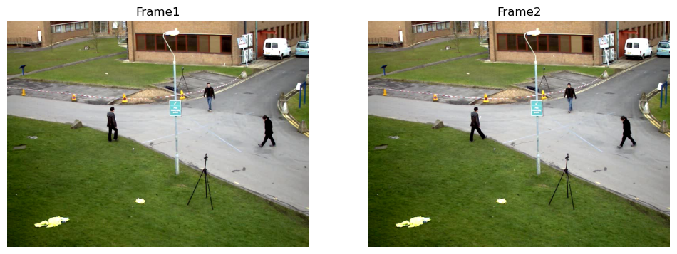

```
[[-0.08181963 -0.03541942]
 [-0.09413008 -0.03923686]
 [-0.11463503 -0.04523205]
 [-0.10710457 -0.04418755]
 [-0.08880045 -0.04090994]
 [-0.11855497 -0.04600687]
 [-0.08618017 -0.03400565]
 [ 0.56767285  0.09361654]
 [ 2.1571603   0.3733273 ]
 [ 2.718743    0.44680595]
 [ 2.9465387   0.48039892]
 [ 3.0230267   0.44275483]
 [ 2.9701855   0.21989511]
 [ 3.0177958   0.06500608]
 [ 3.0498133  -0.02515948]
 [ 3.0556848  -0.11365623]
 [ 3.0340931  -0.19869994]
 [ 2.9597135  -0.2584774 ]
 [ 2.9290593  -0.17568412]
 [ 2.9276907  -0.14340977]
 [ 2.8992105  -0.25520185]
 [ 2.9580104  -0.45614883]
 [ 3.041451   -0.65083295]
 [ 3.0897565  -0.8112713 ]
 [ 3.1520634  -0.923406  ]
 [ 3.2372339  -1.0225408 ]
 [ 3.2348733  -1.0437653 ]
 [ 3.2684143  -0.94847757]
 [ 3.3787763  -0.9477932 ]
 [ 3.4408922  -1.011482  ]
 [ 3.4679456  -1.0343356 ]
 [ 3.5375888  -1.0346838 ]
 [ 3.7999325  -0.9626095 ]
 [ 4.0991535  -0.8869964 ]
 [ 4.1508512  -0.90577143]
 [ 4.455173   -0.6280253 ]
 [ 4.918234   -0.22719   ]
 [ 5.1963687  -0.07053827]
 [ 5.2586927  -0.1789298 ]
 [ 5.2554617  -0.4283411 ]
 [ 5.244395   -0.71602947]
 [ 5.2298937  -1.0419396 ]
 [ 5.2818065  -1.358736  ]
 [ 5.3060746  -1.4489205 ]
 [ 5.2677217  -1.5149922 ]
 [ 5.2190957  -1.7656504 ]
 [ 5.2153196  -2.1316838 ]
 [ 5.071393   -2.8010957 ]
 [ 4.6027675  -3.9373667 ]
 [ 4.817053   -4.544657  ]
 [ 5.4987173  -4.7518377 ]
 [ 8.0373     -2.346777  ]
 [11.148831    0.1007155 ]
 [10.60918     0.33068603]
 [ 8.18874     0.37763652]
 [ 4.926337    0.38103628]
 [ 3.036852    0.38942418]
 [ 1.8988808   0.35843125]
 [ 1.5299664   0.34927183]
 [ 1.2954265   0.3484823 ]]
```

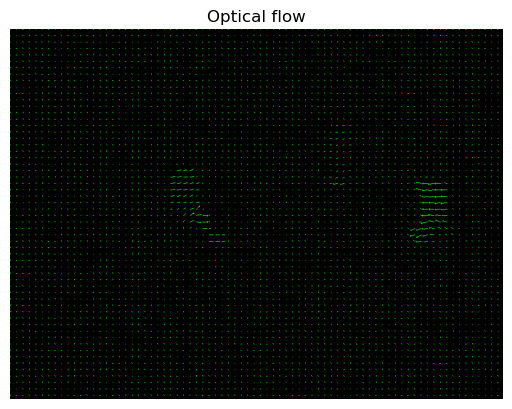

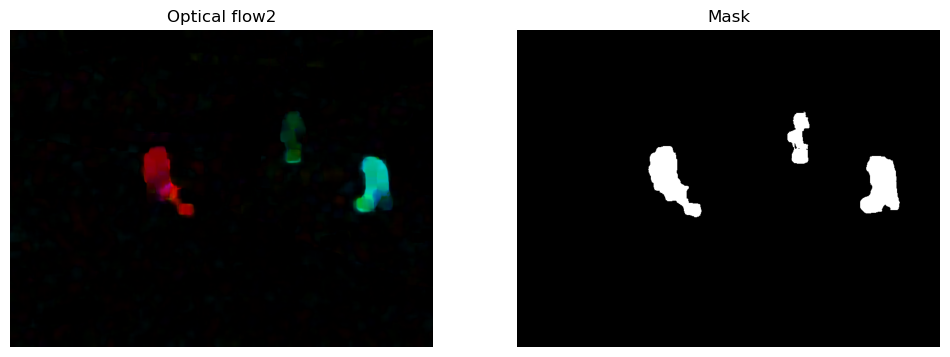

```python
# 读入相邻两帧图像
frame1 = cv2.imread("Images/frame1.png")
frame1_gray = cv2.cvtColor(frame1, cv2.COLOR_BGR2GRAY)

frame2 = cv2.imread("Images/frame2.png")
frame2_gray = cv2.cvtColor(frame2, cv2.COLOR_BGR2GRAY)

plt.figure(1, figsize=(12,10))
plt_show('Frame1', frame1, 121)
plt_show('Frame2', frame2, 122)

# 计算光流（使用默认参数）
flow = cv2.calcOpticalFlowFarneback(frame1_gray, frame2_gray, None, pyr_scale=0.5, levels=3, winsize=15,
                                        iterations=3, poly_n=5, poly_sigma=1.1, flags=0)
print(flow[280, 240:300]) #左边人

#显示光流图
flow_img = np.zeros_like(frame1)
h,w = frame1_gray.shape
for y1 in range(0,h,10):
    for x1 in range(0,w,10):
        flowatxy = flow[y1,x1]
        x2 = int(x1+flowatxy[0])
        y2 = int(y1+flowatxy[1])
        cv2.arrowedLine(flow_img,(x1,y1),(x2,y2),(0,255,0),1)
plt_show('Optical flow', flow_img)

# 采用HSV图像显示光流
hsv = np.zeros_like(frame1)
hsv[:,:, 1] = 255  # 饱和度设为最大
mag, ang = cv2.cartToPolar(flow[:,:, 0], flow[:,:, 1])  #笛卡尔坐标转换成极坐标半径、角度
hsv[:,:, 0] = ang*180/np.pi/2   # 色调表示方向
hsv[:,:, 2] = cv2.normalize(mag, None, 0, 255, cv2.NORM_MINMAX)  # 亮度表示幅度

flow_img2 = cv2.cvtColor(hsv, cv2.COLOR_HSV2BGR) #HSV转成BGR用于显示
plt.figure(3, figsize=(12,10))
plt_show('Optical flow2', flow_img2, 121)

mask = np.zeros_like(frame1_gray)
mask[mag>1.5] = 255
plt_show('Mask', mask, 122) #运动物体掩膜
```

```python
'''视频'''
cap = cv2.VideoCapture("Images/vtest.avi")

# 读取第一帧
ret, frame = cap.read()
prev_gray = cv2.cvtColor(frame, cv2.COLOR_BGR2GRAY)

# 采用HSV图像显示光流
hsv = np.zeros_like(frame)
hsv[..., 1] = 255  # 饱和度设为最大

while(True):
    ret, frame = cap.read()
    if not ret:
        break

    frame_gray = cv2.cvtColor(frame, cv2.COLOR_BGR2GRAY)

    # 计算光流（使用默认参数）
    flow = cv2.calcOpticalFlowFarneback(prev_gray, frame_gray, None, pyr_scale=0.5, levels=3, winsize=15,
                                        iterations=3, poly_n=5, poly_sigma=1.1, flags=0)

    mag, ang = cv2.cartToPolar(flow[..., 0], flow[..., 1])  #笛卡尔坐标转换成极坐标半径、角度

    hsv[..., 0] = ang*180/np.pi/2   # 色调表示方向
    hsv[..., 2] = cv2.normalize(mag, None, 0, 255, cv2.NORM_MINMAX)  # 亮度表示幅度
    bgr = cv2.cvtColor(hsv, cv2.COLOR_HSV2BGR)

    result = np.hstack((frame, bgr))
    cv2.imshow('Optical flow', result)

    # 按下 'q' 键退出
    if cv2.waitKey(1) & 0xFF == ord('q'):
        break

    # 更新前一帧
    prev_gray = frame_gray

# 释放资源
cap.release()
cv2.destroyAllWindows()
```

光流法总结：

Lucas-Kanade方法只需对角点计算光流，计算高效，但有遮挡时易跟踪失败，同时对光照变化敏感，对平滑区域（无角点区域）会失效，对大位移解决能力有限，适用于需要实时性、稀疏输出、硬件资源有限（如嵌入式设备）的情况。

Farneback为每个像素计算位移，因此计算量大，但对遮挡、光照变化、平滑区域以及大位移有更强的鲁棒性，适用于需要稠密光流、处理复杂运动或光照变化、可接受较高计算代价（如服务器端处理）的情况。

经典光流法教学视频：https://www.bilibili.com/video/BV1pV411o7sf?vd_source=a6e8ed60496342db4cb41bb3727806f3&p=9&spm_id_from=333.788.videopod.episodes

https://www.bilibili.com/video/BV1bb4y1x7ai?vd_source=a6e8ed60496342db4cb41bb3727806f3&p=107&spm_id_from=333.788.videopod.episodes

MOOC课程：https://www.icourse163.org/learn/ZJU-1206408807

## 5. 三种运动场景

- 情况1：相机静止，目标运动（如监控摄像头下的行人）
- 情况2：相机运动，目标静止（如移动拍摄静态场景）
- 情况3：相机和目标均运动（如无人机跟踪车辆）

[figure not shown]

**情况3：动态背景下的运动目标检测**

如何分离相机运动（全局光流）和目标运动（残差光流）？

- 相机运动（全局光流）：由相机自身运动（如平移、旋转）引起，影响图像中所有像素，表现为一致的全局运动模式。
- 目标运动（残差光流）：独立运动的物体（如行人、车辆）产生的局部运动，与全局模式偏离的部分。

分离流程：

- 估计全局运动模型（如仿射/单应性变换，可通过最小二乘/RANSAC/特征点配准求解）。
- 用模型预测全局光流，与实际光流对比得到残差。
- 残差光流即为目标运动。

经测试，对于情况3，传统方法效果欠佳，建议采用深度学习方法。